# Simple Linear Regression Workflow

1. Introduction
2. Imports
3. Data Exploration
4. Model Building
5. Results and Evaluation
6. Conclusion

[figure not shown]

# Introduction

> **The Purpose:** To explore the relationship between promotional budgets and the sales generated therefrom.

> **The Goal:** Provide leadership with a clear understanding of the relationship between types of marketing campaigns and the revenue generated as a result of the investment.

# Imports

```python
# Import of relevant Python libraries and modules
import pandas as pd
import matplotlib.pyplot as plt
import seaborn as sns
from statsmodels.formula.api import ols
import statsmodels.api as sm
```

## Loading the Dataset into a Dataframe

```python
# Dataset loaded and saved as a variable
data = pd.read_csv("marketing_sales_data.csv")
```

# Data Exploration

```python
# Exploring the dataset
data.head()
```

|  | TV | Radio | Social Media | Influencer | Sales |
| --- | --- | --- | --- | --- | --- |
| 0 | Low | 1.218354 | 1.270444 | Micro | 90.054222 |
| 1 | Medium | 14.949791 | 0.274451 | Macro | 222.741668 |
| 2 | Low | 10.377258 | 0.061984 | Mega | 102.774790 |
| 3 | High | 26.469274 | 7.070945 | Micro | 328.239378 |
| 4 | High | 36.876302 | 7.618605 | Mega | 351.807328 |

**Observations:**

- This dataset includes the following information:
> - TV Promotion budget (expressed as "Low", "Medium", or "High")
> - Radio promotion budget
> - Social media promotion budget
> - Type of influencer that the promotion is in collaboration with (expressed as "Mega", "Macro","Micro", or "Nano")
> - Sales accured from the promtion

```python
# Continued exploration
data.shape
```

```
(572, 5)
```

> - There are 572 **rows** (*companies*) and 5 **columns** (*aspects about each company*) represented in this dataset.

### Checking for missing values in the rows of the data.

```python
# Getting booleans indicating whether each value in the data is missing
data.isna()
```

|  | TV | Radio | Social Media | Influencer | Sales |
| --- | --- | --- | --- | --- | --- |
| 0 | False | False | False | False | False |
| 1 | False | False | False | False | False |
| 2 | False | False | False | False | False |
| 3 | False | False | False | False | False |
| 4 | False | False | False | False | False |
| ... | ... | ... | ... | ... | ... |
| 567 | False | False | False | False | False |
| 568 | False | False | False | False | False |
| 569 | False | False | False | False | False |
| 570 | False | False | False | False | False |
| 571 | False | False | False | False | False |

572 rows × 5 columns

```python
# Getting booleans indicating whether there are any missing values along the columns in each row
data.isna().any(axis=1)
```

```
0      False
1      False
2      False
3      False
4      False
       ...
567    False
568    False
569    False
570    False
571    False
Length: 572, dtype: bool
```

```python
# Using sum to get the number of rows that contain missing values
data.isna().any(axis=1).sum()
```

```
3
```

### Dropping the rows containing missing values

```python
# Dropping rows that contain missing values
data = data.dropna(axis=0)
```

```python
# Checking that data no longer contains rows with missing values
data.isna().any(axis=1).sum()
```

```
0
```

### Checking model assumptions

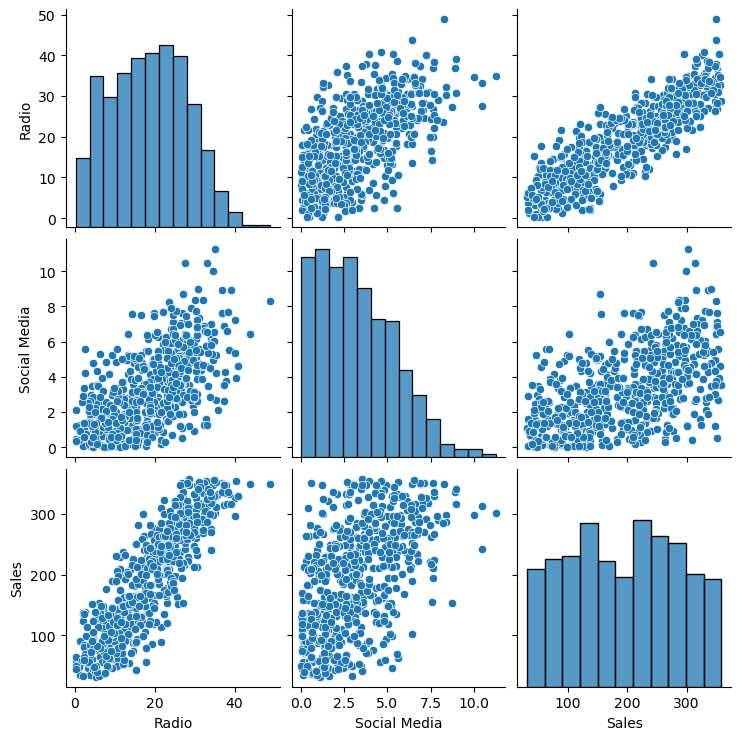

```python
# Creating a plot of pairwise relationships between variables
sns.pairplot(data)
```

**Observations:**

> - In the scatter plot of `Sales` over `Radio`, the points appear to cluster around a line indicating a positive association between the two variables.
> - As a result, it seems the assumption of linearity is met.

# Model Building

```python
# selecting columns needed for the model
# Saving resulting dataframe
ols_data = data[["Radio", "Sales"]]
```

```python
# Exploring to ensure accuracy
ols_data.head(10)
```

|  | Radio | Sales |
| --- | --- | --- |
| 0 | 1.218354 | 90.054222 |
| 1 | 14.949791 | 222.741668 |
| 2 | 10.377258 | 102.774790 |
| 3 | 26.469274 | 328.239378 |
| 4 | 36.876302 | 351.807328 |
| 5 | 25.561910 | 261.966812 |
| 6 | 37.263819 | 349.861575 |
| 7 | 13.187256 | 140.415286 |
| 8 | 29.520170 | 264.592233 |
| 9 | 3.773287 | 55.674214 |

> - I'll now write the linear regression formula for modeling the relationship between the two variables of interest.

```python
# Writing the linear regression formula
# Saving it in a variable
ols_formula = "Sales ~ Radio"
```

### Implementing the Ordinary Least Squares (OLS) approach for linear regression

```python
# Implementing OLS
OLS = ols(formula = ols_formula, data = ols_data)
```

### Creating a linear regression model for data and fitting the model to the data

```python
# Fitting model to the data
# Saving the fitted model in a variable
model = OLS.fit()
```

# Results and Evaluation

```python
# Getting a summary of the model results
model.summary()
```

OLS Regression Results

| Dep. Variable: | Sales | R-squared: | 0.757 |
| --- | --- | --- | --- |
| Model: | OLS | Adj. R-squared: | 0.757 |
| Method: | Least Squares | F-statistic: | 1768. |
| Date: | Wed, 12 Feb 2025 | Prob (F-statistic): | 2.07e-176 |
| Time: | 17:57:38 | Log-Likelihood: | -2966.7 |
| No. Observations: | 569 | AIC: | 5937. |
| Df Residuals: | 567 | BIC: | 5946. |
| Df Model: | 1 |  |  |
| Covariance Type: | nonrobust |  |  |

|  | coef | std err | t | P>\|t\| | [0.025 | 0.975] |
| --- | --- | --- | --- | --- | --- | --- |
| Intercept | 41.5326 | 4.067 | 10.211 | 0.000 | 33.544 | 49.521 |
| Radio | 8.1733 | 0.194 | 42.048 | 0.000 | 7.791 | 8.555 |

| Omnibus: | 2.267 | Durbin-Watson: | 1.880 |
| --- | --- | --- | --- |
| Prob(Omnibus): | 0.322 | Jarque-Bera (JB): | 2.221 |
| Skew: | -0.102 | Prob(JB): | 0.329 |
| Kurtosis: | 2.772 | Cond. No. | 45.7 |

Notes:  
[1] Standard Errors assume that the covariance matrix of the errors is correctly specified.

**Observations:**

> - The y-intercept is: 41.5326
> - The slope is: 8.1733
> - The slope here may imply that if a company has a budget of 1 million dollars for promoting their products/service on the radio, the company's sales would increase by 8.1733 million dollars on average.

### Finishing the check of model assumptions

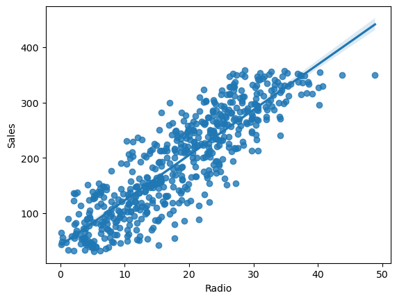

```python
# Plotting the OLS data with the best fit regression line
sns.regplot(x = "Radio", y = "Sales", data = ols_data)
```

**Observation:**

> - The preceding regression plot illustrates an approximately linear relationship between the two variables along with the best fit line.
> - This confirms the assumption of linearity.

### Checking the normality assumption

```python
# Getting residuals from the model
residuals = model.resid
```

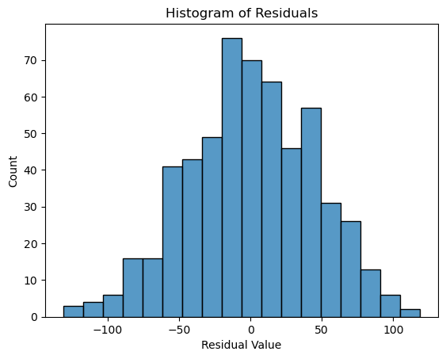

```python
# Visualizing the distribution of the residuals
fig = sns.histplot(residuals)
fig.set_xlabel("Residual Value")
fig.set_title("Histogram of Residuals")
plt.show()
```

**Observation:**

> - Based on the preceding visualization, the distribution of the residuals is approximately normal.
> - This indicates that the assumption of normality is likely met.

### Creating a Q-Q plot to confirm the assumption of normality

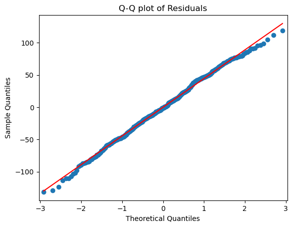

```python
# Creating a Q-Q plot
sm.qqplot(residuals, line='s')
plt.title("Q-Q plot of Residuals")
plt.show()
```

**Observation:**

> - In the preceding Q-Q plot, the points closely follow a straight diagonal line trending upward.
> - This confirms that the normality assumption is met.

### Checking the assumptions of independent observation and homoscedasticity

```python
# Getting fitted values
fitted_values = model.predict(ols_data["Radio"])
```

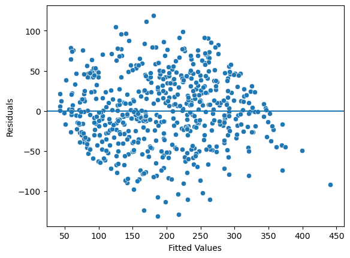

```python
# Creating a scatterplot of residuals against fitted values
fig = sns.scatterplot(x=fitted_values, y=residuals)
fig.axhline(0)
fig.set_xlabel("Fitted Values")
fig.set_ylabel("Residuals")
plt.show()
```

**Observation:**

> - In the preceding scatterplot, the data points have a cloud-like resemblance and do not follow an explicit pattern.
> - So it appears that the independent observation assumption has not been violated.
> - Given that the residuals appear to be randomly spaced, the homoscedasticity assumption seems to have been met.

# Conclusion

> - In this simple linear regression model, the y-intercept is 41.5326 and the slope is 8.1733. One interpretation: If a company has a budget of 1 million dollars more for promoting their products/services on the radio, the company's sales would increase by 8.1733 million dollars on average.Another interpretation: Companies with 1 million dollars more in their radio promotion budget accrue 8.1733 million dollars more in sales on average.
> - The results are statistically significant with a p-value of 0.000, which is a very small value (and smaller than the common significance level of 0.05). This indicates that there is a very low probability of observing data as extreme or more extreme than this dataset when the null hypothesis is true. In this context, the null hypothesis is that there is no relationship between radio promotion budget and sales i.e. the slope is zero, and the alternative hypothesis is that there is a relationship between radio promotion budget and sales i.e. the slope is not zero. So, in this case I should reject the null hypothesis and state that there is a relationship between radio promotion budget and sales for companies in this dataset.
> - The slope of the line of best fit that resulted from the regression model is approximate and subject to uncertainty (not the exact value). The 95% confidence interval for the slope is from 7.791 to 8.555. This indicates that there is a 95% probability that the interval [7.791, 8.555] contains the true value for the slope.

## Communication to Stakeholders

> - Based on the dataset at hand and the regression analysis conducted here, there is a notable relationship between radio promotion budget and sales for companies in this dataset, with a p-value of 0.000 and standard error of 0.194. For companies represented by this data, a 1 million dollar increase in radio promotion budget could be associated with a 8.1733 million dollar increase in sales. It would be worth continuing to promote products/services on the radio. Also, it is recommended to consider further examining the relationship between the two variables (radio promotion budget and sales) in different contexts. For example, it would help to gather more data to understand whether this relationship is different in certain industries or when promoting certain types of products/services.